# 2b Top genes annotations

This script annotates the top genes associated with each archetype in terms of (sub)modules and GO enrichment, and cell specifity

```r
knitr::opts_knit$set(root.dir = rprojroot::find_rstudio_root_file())
knitr::opts_chunk$set(echo = TRUE, warning=FALSE, message=FALSE, cache=TRUE, cache.extra = R.version)
```

```r
suppressPackageStartupMessages({
  library(clusterProfiler)
  library(GOsummaries)
  library(vcd)
  library(tidyverse)
  })
```

# Input

```r
topgenes <- readRDS("analyses/rnaseq/1_fit_archetypes/topgenes_logFC_k3p20_AD.RDS")

submodules <- read.csv(file="data/milind2019/submodules.csv", na.strings = "") %>%
  dplyr::filter(Cohort=="rosmap") %>%
  droplevels()
bigmodules <- read.csv(file="data/milind2019/bigmodules.csv", na.strings = "") %>%
  dplyr::filter(Cohort=="rosmap") %>%
  droplevels()

# cell-specific markers from McKenzie et al. 2017
hum.specific <- read.csv("data/McKenzie_2017_Brain_Cell_Specific_Markers_Human_Specificity.csv", header=T, stringsAsFactors=F)
```

# Modules and submodules enrichment

Add information about modules and submodules to top genes  
Add their HGNC.ID as well, consistent with those in NM’s submodules

```r
topgenes <- topgenes %>%
  left_join(select(bigmodules, Ensembl.ID, Module), by = "Ensembl.ID") %>%
  left_join(select(submodules, Ensembl.ID, Module, Submodule), by =c("Ensembl.ID", "Module")) %>%
  select(Ensembl.ID, HGNC.ID, Module, Submodule, everything())
```

How many of the top genes are in one of the modules/submodules?

```r
cat(round(100*length(which(!is.na(topgenes$Submodule)))/nrow(topgenes)), "% of topgenes are in one of the submodules", "\n") # 62% in the submodules
```

```
## 62 % of topgenes are in one of the submodules
```

```r
cat(round(100*length(which(!is.na(topgenes$Module)))/nrow(topgenes)), "% of topgenes are in one of the modules", "\n") # 84% in the big modules
```

```
## 85 % of topgenes are in one of the modules
```

```r
data <- select(topgenes, Module, Archetype) %>%
  mutate(Module=substring(Module, 6))
mytable <- xtabs(~ Module + Archetype, data)
ftable(mytable) # print table
```

```
##           Archetype Archetype_1 Archetype_2 Archetype_3
## Module
## blue                        250         276           1
## brown                        40         118           1
## turquoise                   131          11          66
## yellow                        0           0         743
```

```r
summary(mytable) # chi-square test of indepedence
```

```
## Call: xtabs(formula = ~Module + Archetype, data = data)
## Number of cases in table: 1637
## Number of factors: 2
## Test for independence of all factors:
##  Chisq = 1666.7, df = 6, p-value = 0
```

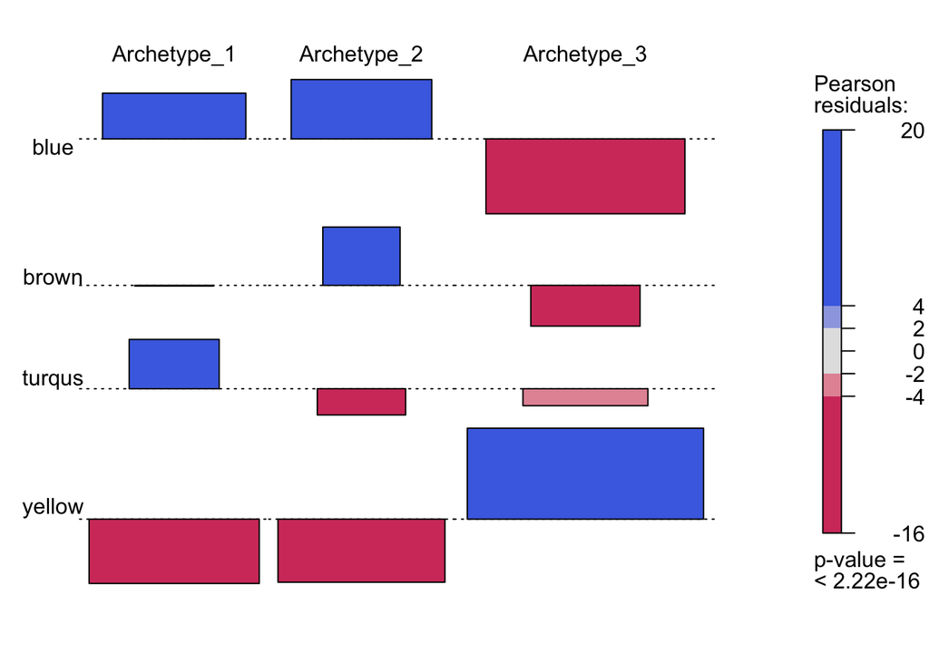

```r
assoc(mytable, shade=TRUE, labeling_args = list(abbreviate_labs = c(Module=6), varnames=c(FALSE,FALSE), rot_labels=c(0,0)))
```

```r
pdf(file = "analyses/rnaseq/2b_topgenes_annotations/chi2_modules.pdf")
assoc(mytable, shade=TRUE,labeling_args = list(abbreviate_labs = c(Module=6), varnames=c(FALSE,FALSE), rot_labels=c(0,0)))
dev.off()
```

```r
data <- select(topgenes, Submodule, Archetype) %>%
  mutate(Submodule=substring(Submodule, 6))
mytable <- xtabs(~ Submodule + Archetype, data)
ftable(mytable) # print table
```

```
##             Archetype Archetype_1 Archetype_2 Archetype_3
## Submodule
## blue_1                          4         199           0
## blue_2                        100           5           0
## blue_3                         93           0           0
## blue_4                          4          20           0
## brown_1                         4          49           0
## brown_2                         5          10           0
## turquoise_1                     0           4          50
## turquoise_2                   101           0           0
## yellow_1                        0           0         528
## yellow_2                        0           0           1
## yellow_3                        0           0          16
```

```r
summary(mytable) # chi-square test of indepedence
```

```
## Call: xtabs(formula = ~Submodule + Archetype, data = data)
## Number of cases in table: 1193
## Number of factors: 2
## Test for independence of all factors:
##  Chisq = 2210.9, df = 20, p-value = 0
##  Chi-squared approximation may be incorrect
```

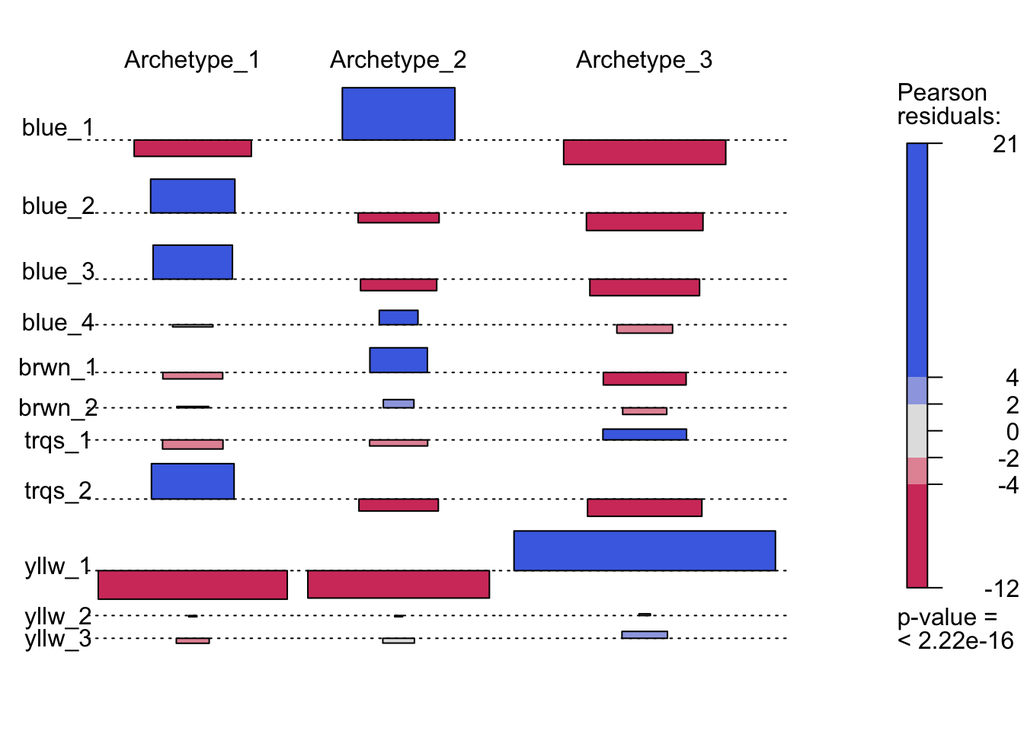

```r
assoc(mytable, shade=TRUE, labeling_args = list(abbreviate_labs = c(Submodule=6), varnames=c(FALSE,FALSE), rot_labels=c(0,0)))
```

```r
pdf(file = "analyses/rnaseq/2b_topgenes_annotations/chi2_submodules.pdf")
assoc(mytable, shade=TRUE, labeling_args = list(abbreviate_labs = c(Submodule=6), varnames=c(FALSE,FALSE), rot_labels=c(0,0)))
dev.off()
```

arch3_B yellow_1: trans-synaptic signaling

arch2, A+B blue_1: astrocyte metabolism; catabolic; oxydation-reduction blue_4: astrocyte and microglia activation; cellular motility & regeneration brown_1: gliogenesis; oligodendrocytic myelination and lysosomal activity

arch1, A blue_2: cytokine (immune) signaling; inflamatory blue_3: microglial activation; immune response regulation turquoise_2: protein folding; cellular response to stress

# GO annotations for topgenes

```r
archetypes <- unique(topgenes$Archetype)

all.go <- c()
for (arch in archetypes) {
    cat("Annotating: ", arch, "\n")
# translate ensembl ID to entrez ID
 eg <- bitr(topgenes[topgenes$Archetype == arch, "Ensembl.ID"], fromType="ENSEMBL", toType="ENTREZID", OrgDb="org.Hs.eg.db")

  # Annotate module
  goBP.anno <- enrichGO(gene=eg[,2], ont = "BP", pAdjustMethod = "BH", pvalueCutoff = 0.01, qvalueCutoff=0.05, OrgDb="org.Hs.eg.db", readable=TRUE)
  goBP.anno <- as.data.frame(goBP.anno@result)

  # Add to data frame
  if (nrow(goBP.anno) > 0) {
    all.go <- rbind(all.go, cbind("Archetype"=arch, goBP.anno))
  }
}
```

```
## Annotating:  Archetype_1
## Annotating:  Archetype_2
## Annotating:  Archetype_3
```

```r
colnames(all.go)[2] <- "GO.ID"
colnames(all.go)[9] <- "HGNC.ID"

# write out lists to generate tag clouds with REVIGO
for (arch in archetypes) {
  all.go %>%
    dplyr::filter(Archetype==arch) %>%
    dplyr::select(GO.ID, p.adjust) %>%
    write_tsv(paste0("analyses/rnaseq/2b_topgenes_annotations/REVIGO_",arch, ".tsv"))
}

## GOsummaries and cloud plots
gs_arch <- list()
for (arch in archetypes) {
  gs_arch[[arch]] <- topgenes %>%
    dplyr::filter(Archetype==arch) %>%
    dplyr::select(HGNC.ID) %>%
    GOsummaries::gosummaries() %>%
    GOsummaries::add_to_slot.gosummaries("Title", list(arch))
}

for (arch in archetypes) {
  plot(gs_arch[[arch]],filename=paste0("analyses/rnaseq/2b_topgenes_annotations/GOcloud_",arch,".pdf"))
}
```

# Cell specificity for top genes

Following Nikil’s 6a_submodule_annotation.Rmd Cell type markers in the brain are taken from McKenzie et al. (Supplemental File 1, DOI:10.1038/s41598-018-27293-5). The study developed three different metrics to rank the relation of genes to specific cell types (enrichment, expression, specificity). The cell specificity for a given gene is the minimum log fold change when pairwise comparing the expression of the gene in the given cell type with the expression of the gene in all other cell types. Here I’m using cell specificity score to annotate the top genes of each archetype, with chi-square to test for biased representations of any cell type in any archetype, and a plot of deviations from expectation for visualization.

```r
archetypes <- sort(unique(topgenes$Archetype))
#NUM.MARKERS = 100

# split topgenes into a list of gene sets by archetype
gene.sets <- split(topgenes, topgenes$Archetype, drop=TRUE) %>%
  lapply(function(l){dplyr::select(l, HGNC.ID)})

cell.types <- c("Astroctyes", "Endothelial", "Microglia", "Neurons", "Oligodendrocytes")

hum.specific <- split(hum.specific, hum.specific$Celltype, drop=TRUE) %>%
  lapply(function(l){dplyr::select(l, HGNC.ID=gene, Grand.Mean=grand_mean)})
names(hum.specific) <- cell.types

# Number of marker genes for each cell type in each archetype gene set
specific.set <- sapply(archetypes, function(s) {
  sapply(cell.types, function(ct) length(intersect(hum.specific[[ct]]$HGNC.ID, gene.sets[[s]]$HGNC.ID)), USE.NAMES=T)
})

names(dimnames(specific.set)) <- c("Cell Type", "Archetype")
chisq.test(specific.set)
```

```
##
##  Pearson's Chi-squared test
##
## data:  specific.set
## X-squared = 1197.4, df = 8, p-value < 2.2e-16
```

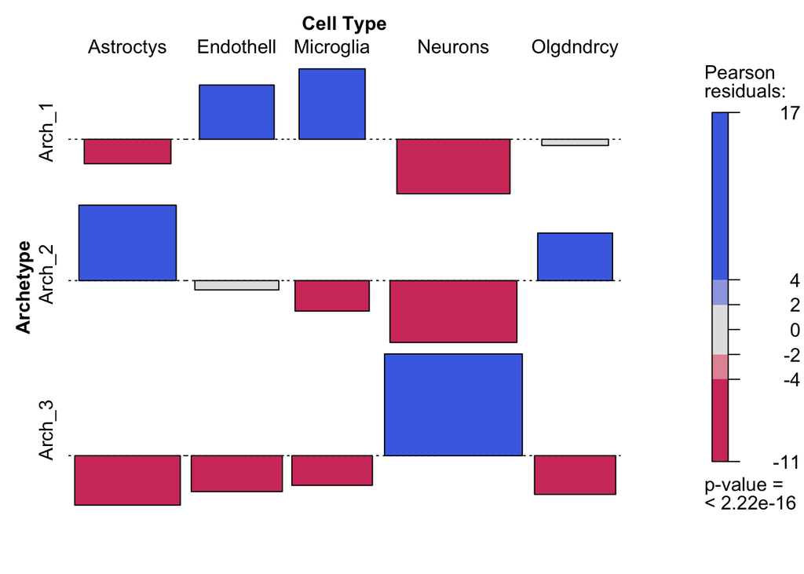

```r
assoc(t(specific.set), shade=TRUE,labeling_args = list(abbreviate_labs = c(6, 9)))
```

```r
pdf(file = "analyses/rnaseq/2b_topgenes_annotations/cellTypes.pdf")
assoc(t(specific.set), shade=TRUE,labeling_args = list(abbreviate_labs = c(6, 9)))
dev.off()
```

```r
#
```

# Output

```r
saveRDS(topgenes, "analyses/rnaseq/2b_topgenes_annotations/topgenes.anno.RDS")
saveRDS(all.go, file="analyses/rnaseq/2b_topgenes_annotations/all.GO_archetypes.RDS")
```